# Cwong Assign3

Calvin Wong

2/22/2019

ASSIGNMENT 4

IS 605 FUNDAMENTALS OF COMPUTATIONAL MATHEMATICS - 2014

1. Problem Set 1

In this problem, we’ll verify using R that SVD and Eigenvalues are related as worked out in the weekly module. Given a 3 X 2 matrix A, write code in R to compute X = AAT and Y = ATA. Then, compute the eigenvalues and eigenvectors of X and Y using the built-in commans in R.

```r
A = matrix(c(1,-1,2,0,3,4),nrow=2,ncol=3)

X = A %*% t(A)
X
```

```
##      [,1] [,2]
## [1,]   14   11
## [2,]   11   17
```

```r
Y = t(A) %*% A
Y
```

```
##      [,1] [,2] [,3]
## [1,]    2    2   -1
## [2,]    2    4    6
## [3,]   -1    6   25
```

```r
eX = eigen(X)
print(list(eX$values, eX$vectors))
```

```
## [[1]]
## [1] 26.601802  4.398198
##
## [[2]]
##           [,1]       [,2]
## [1,] 0.6576043 -0.7533635
## [2,] 0.7533635  0.6576043
```

```r
eY = eigen(Y)
print(list(eY$values, eY$vectors))
```

```
## [[1]]
## [1] 2.660180e+01 4.398198e+00 1.058982e-16
##
## [[2]]
##             [,1]       [,2]       [,3]
## [1,] -0.01856629 -0.6727903  0.7396003
## [2,]  0.25499937 -0.7184510 -0.6471502
## [3,]  0.96676296  0.1765824  0.1849001
```

```r
decomposedA = svd(A)
print(c(list(decomposedA$u,decomposedA$v,decomposedA$d)))
```

```
## [[1]]
##            [,1]       [,2]
## [1,] -0.6576043 -0.7533635
## [2,] -0.7533635  0.6576043
##
## [[2]]
##             [,1]       [,2]
## [1,]  0.01856629 -0.6727903
## [2,] -0.25499937 -0.7184510
## [3,] -0.96676296  0.1765824
##
## [[3]]
## [1] 5.157693 2.097188
```

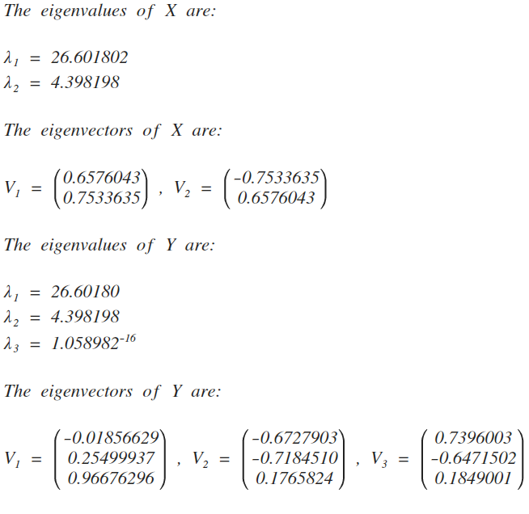

Then, compute the left-singular, singular values, and right-singular vectors of A using the svd command. Examine the two sets of singular vectors and show that they are indeed eigenvectors of X and Y. In addition, the two non-zero eigenvalues (the 3rd value will be very close to zero, if not zero) of both X and Y are the same and are squares of the non-zero singular values of A. Your code should compute all these vectors and scalars and store them in variables. Please add enough comments in your code to show me how to interpret your steps.

```r
(svd_a <- svd(A))
```

```
## $d
## [1] 5.157693 2.097188
##
## $u
##            [,1]       [,2]
## [1,] -0.6576043 -0.7533635
## [2,] -0.7533635  0.6576043
##
## $v
##             [,1]       [,2]
## [1,]  0.01856629 -0.6727903
## [2,] -0.25499937 -0.7184510
## [3,] -0.96676296  0.1765824
```

We can see that the left-singular vectors (u) contains eigenvectors of X and right-singular vectors (v) contains eigen vectors of Y, although the value’s have the opposite sign, they are equivalent because of scalar multiplicity.

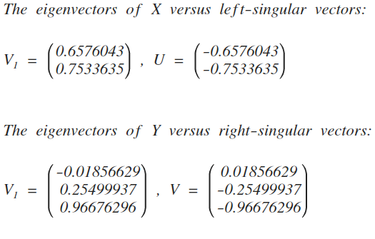

```r
(d_sq <- svd_a$d^2)
```

```
## [1] 26.601802  4.398198
```

```r
eX$values
```

```
## [1] 26.601802  4.398198
```

```r
eY$values
```

```
## [1] 2.660180e+01 4.398198e+00 1.058982e-16
```

The two non-zero eigenvalues of both X and Y and the square of the non-zero singular values of A are the same.

2. Problem Set 2 Using the procedure outlined in section 1 of the weekly handout, write a function to compute the inverse of a well-conditioned full-rank square matrix using co-factors. In order to compute the co-factors, you may use built-in commands to compute the determinant. Your function should have the following signature: B = myinverse(A) where A is a matrix and B is its inverse and AXB = I. The off-diagonal elements of I should be close to zero, if not zero. Likewise, the diagonal elements should be close to 1, if not 1. Small numerical precision errors are acceptable but the function myinverse should be correct and must use co-factors and determinant of A to compute the inverse. Please submit PS1 and PS2 in an R-markdown document with your first initial and last name.

```r
myInverse = function(A){
  #Tests if the matrix is square
  if(dim(A)[1] != dim(A)[2])
  {
    return('ERROR : Matrix is not square')
  }

  #Tests if the matrix determinant is equal 0

  if(det(A) == 0)
  {
    return('ERROR : Matrix is singular')
  }

  #Create co-factor matrix
  coMatrix = A * 0

  #Cofactoring proceedure
  for (i in 1:ncol(A))
  {
    for (j in 1:nrow(A))
    {
      coMatrix[i,j] = det(A[-i,-j]) * (-1)^(i+j)
    }
  }

  inversed = t((coMatrix)/det(A))

  return(inversed)
}
```

```r
#From earlier 2x3 matrix
myInverse(A)
```

```
## [1] "ERROR : Matrix is not square"
```

TEST: Works with a 2X3 matrix

```r
C = matrix(c(1, 2, 3, 1, 1, 1, 2, 0, 1), nrow=3)
D = myInverse(C)
round(C %*% D)
```

```
##      [,1] [,2] [,3]
## [1,]    1    0    0
## [2,]    0    1    0
## [3,]    0    0    1
```

TEST: Shows matrix calculated with myinverse is equal to the inverse.